# p8130 HW4 Regression

Eleanor Zhang

11/11/2018

## Problem 2 Heart disease

We are interested in fi there is an association between **total cost** in dollars diagnosed with heart disease and the **number of ER visits**. Other factors will be adjusted later on.

### a) short description of data and look at the data

```r
heart_disease <- read_csv("./data/HeartDisease.csv")
head(heart_disease)
```

```
## # A tibble: 6 x 10
##      id totalcost   age gender interventions drugs ERvisits complications
##   <int>     <dbl> <int>  <int>         <int> <int>    <int>         <int>
## 1     1      179.    63      0             2     1        4             0
## 2     2      319     59      0             2     0        6             0
## 3     3     9311.    62      0            17     0        2             0
## 4     4      281.    60      1             9     0        7             0
## 5     5    18727.    55      0             5     2        7             0
## 6     6      453.    66      0             1     0        3             0
## # ... with 2 more variables: comorbidities <int>, duration <int>
```

```r
skimr::skim(heart_disease)
```

```
## Skim summary statistics
##  n obs: 788
##  n variables: 10
##
## ── Variable type:integer ───────────────────────────────────────────────────────────────────────────────────
##       variable missing complete   n    mean     sd p0    p25   p50    p75
##            age       0      788 788  58.72    6.75 24  55     60    64
##  comorbidities       0      788 788   3.77    5.95  0   0      1     5
##  complications       0      788 788   0.057   0.25  0   0      0     0
##          drugs       0      788 788   0.45    1.06  0   0      0     0
##       duration       0      788 788 164.03  120.92  0  41.75 165.5 281
##       ERvisits       0      788 788   3.43    2.64  0   2      3     5
##         gender       0      788 788   0.23    0.42  0   0      0     0
##             id       0      788 788 394.5   227.62  1 197.75 394.5 591.25
##  interventions       0      788 788   4.71    5.59  0   1      3     6
##  p100     hist
##    70 ▁▁▁▁▂▆▇▆
##    60 ▇▁▁▁▁▁▁▁
##     3 ▇▁▁▁▁▁▁▁
##     9 ▇▁▁▁▁▁▁▁
##   372 ▇▃▃▃▃▃▅▃
##    20 ▇▇▂▁▁▁▁▁
##     1 ▇▁▁▁▁▁▁▂
##   788 ▇▇▇▇▇▇▇▇
##    47 ▇▂▁▁▁▁▁▁
##
## ── Variable type:numeric ───────────────────────────────────────────────────────────────────────────────────
##   variable missing complete   n    mean      sd p0    p25   p50     p75
##  totalcost       0      788 788 2799.96 6690.26  0 161.12 507.2 1905.45
##     p100     hist
##  52664.9 ▇▁▁▁▁▁▁▁
```

```r
str(heart_disease)
```

[output not shown]

```r
names(heart_disease)
```

```
##  [1] "id"            "totalcost"     "age"           "gender"
##  [5] "interventions" "drugs"         "ERvisits"      "complications"
##  [9] "comorbidities" "duration"
```

In this dataset, there are 788 observations of patients with 10 variables:

- **id**: patient id
- **totalcost**: total cost ($) of patients who are diagnosed with heart disease
- **age**: age of patients
- **interventions**: number of interventions (integers)
- **drugs**: ? number/type of drugs.
- **ERvisits**: number of ER visits
- **complications**: have complications (1) or not (0)
- **comorbidities**: number of co-presence of other diseases in additional to heart disease
- **duration**: duration of heart disease (in days)

Based our investigation interest, the main outcome is **total cost** of patients with heart disease and the main predictor is **ERvisits** (number of ER visits). Other important covariates also need to be considered because they could potential have differential effect on the association relationship between out main predictor and main outcome, including age, interventions, drugs used, complications, and duration of disease. We will first take a look at these variables:

1. First we took a look at the main outcome and main predictor

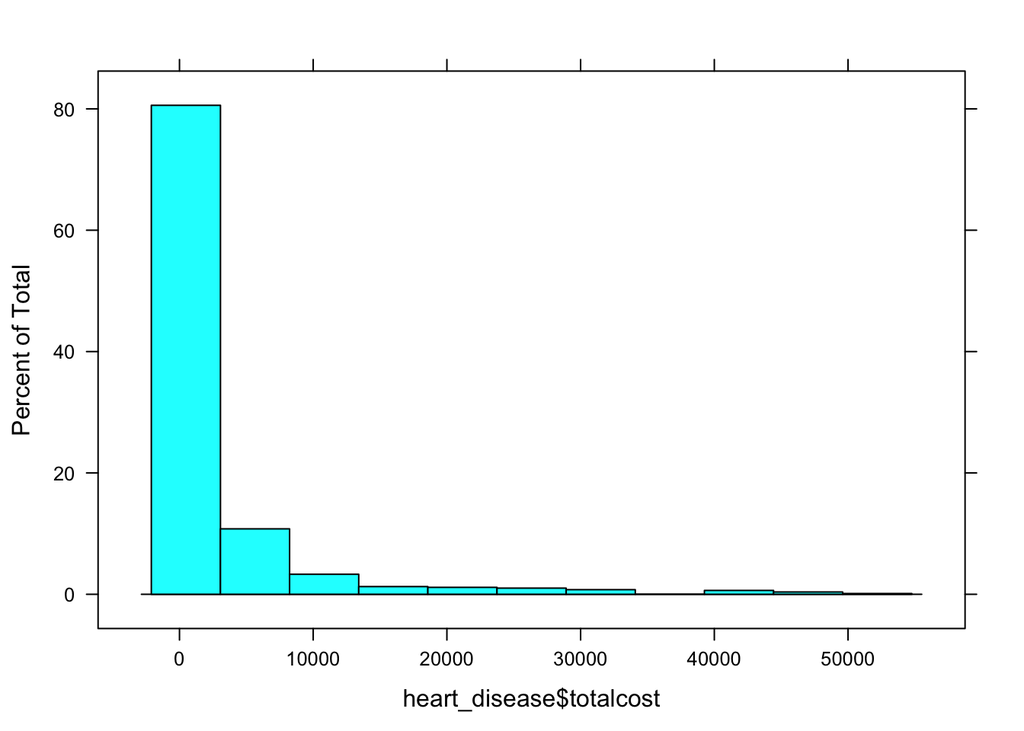

```r
par(mfrow = c(1,2))
histogram(heart_disease$totalcost)
```

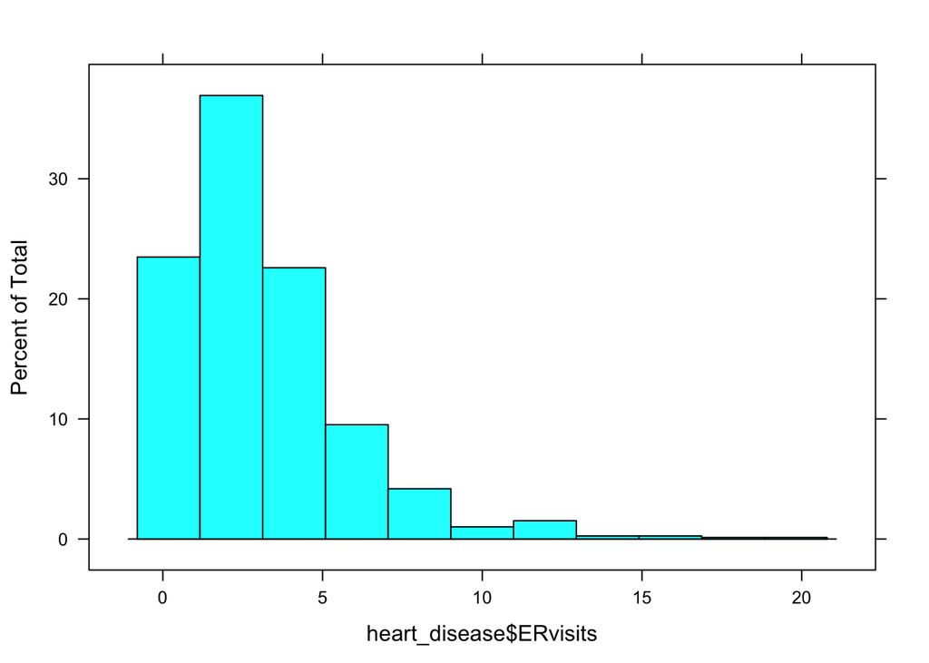

```r
histogram(heart_disease$ERvisits)
```

```r
knitr::kable(summary(heart_disease))
```

|  | id | totalcost | age | gender | interventions | drugs | ERvisits | complications | comorbidities | duration |
| --- | --- | --- | --- | --- | --- | --- | --- | --- | --- | --- |
|  | Min. : 1.0 | Min. : 0.0 | Min. :24.00 | Min. :0.0000 | Min. : 0.000 | Min. :0.0000 | Min. : 0.000 | Min. :0.00000 | Min. : 0.000 | Min. : 0.00 |
|  | 1st Qu.:197.8 | 1st Qu.: 161.1 | 1st Qu.:55.00 | 1st Qu.:0.0000 | 1st Qu.: 1.000 | 1st Qu.:0.0000 | 1st Qu.: 2.000 | 1st Qu.:0.00000 | 1st Qu.: 0.000 | 1st Qu.: 41.75 |
|  | Median :394.5 | Median : 507.2 | Median :60.00 | Median :0.0000 | Median : 3.000 | Median :0.0000 | Median : 3.000 | Median :0.00000 | Median : 1.000 | Median :165.50 |
|  | Mean :394.5 | Mean : 2800.0 | Mean :58.72 | Mean :0.2284 | Mean : 4.707 | Mean :0.4467 | Mean : 3.425 | Mean :0.05711 | Mean : 3.767 | Mean :164.03 |
|  | 3rd Qu.:591.2 | 3rd Qu.: 1905.5 | 3rd Qu.:64.00 | 3rd Qu.:0.0000 | 3rd Qu.: 6.000 | 3rd Qu.:0.0000 | 3rd Qu.: 5.000 | 3rd Qu.:0.00000 | 3rd Qu.: 5.000 | 3rd Qu.:281.00 |
|  | Max. :788.0 | Max. :52664.9 | Max. :70.00 | Max. :1.0000 | Max. :47.000 | Max. :9.0000 | Max. :20.000 | Max. :3.00000 | Max. :60.000 | Max. :372.00 |